# Coffee Shop comprehensive analysis

2024-04-28

```r
# Load necessary libraries
library(readxl)
library(dplyr)
```

```r
library(tidyr)
library(ggplot2)
library(lubridate)
library(caret)
library(forecast)
library(tseries)
# Read the data
sales_Original_data <- read_excel("E:/R Final Project/Coffee Shop Sales.xlsx")
```

## Data Cleaning

```r
########################### Data cleaning ################################

#Checking the dataset
colnames(sales_Original_data)
```

```
##  [1] "transaction_id"   "transaction_date" "transaction_time" "transaction_qty"
##  [5] "store_id"         "store_location"   "product_id"       "unit_price"
##  [9] "product_category" "product_type"     "product_detail"
```

```r
head(sales_Original_data)
```

```
## # A tibble: 6 × 11
##   transaction_id transaction_date    transaction_time    transaction_qty
##            <dbl> <dttm>              <dttm>                        <dbl>
## 1              1 2023-01-01 00:00:00 1899-12-31 07:06:11               2
## 2              2 2023-01-01 00:00:00 1899-12-31 07:08:56               2
## 3              3 2023-01-01 00:00:00 1899-12-31 07:14:04               2
## 4              4 2023-01-01 00:00:00 1899-12-31 07:20:24               1
## 5              5 2023-01-01 00:00:00 1899-12-31 07:22:41               2
## 6              6 2023-01-01 00:00:00 1899-12-31 07:22:41               1
## # ℹ 7 more variables: store_id <dbl>, store_location <chr>, product_id <dbl>,
## #   unit_price <dbl>, product_category <chr>, product_type <chr>,
## #   product_detail <chr>
```

```r
summary(sales_Original_data)
```

```
##  transaction_id   transaction_date
##  Min.   :     1   Min.   :2023-01-01 00:00:00.00
##  1st Qu.: 37336   1st Qu.:2023-03-06 00:00:00.00
##  Median : 74728   Median :2023-04-24 00:00:00.00
##  Mean   : 74737   Mean   :2023-04-15 11:50:32.17
##  3rd Qu.:112094   3rd Qu.:2023-05-30 00:00:00.00
##  Max.   :149456   Max.   :2023-06-30 00:00:00.00
##  transaction_time                 transaction_qty    store_id
##  Min.   :1899-12-31 06:00:00.00   Min.   :1.000   Min.   :3.000
##  1st Qu.:1899-12-31 09:05:11.50   1st Qu.:1.000   1st Qu.:3.000
##  Median :1899-12-31 11:15:28.00   Median :1.000   Median :5.000
##  Mean   :1899-12-31 12:14:16.82   Mean   :1.438   Mean   :5.342
##  3rd Qu.:1899-12-31 15:25:57.00   3rd Qu.:2.000   3rd Qu.:8.000
##  Max.   :1899-12-31 20:59:32.00   Max.   :8.000   Max.   :8.000
##  store_location       product_id      unit_price     product_category
##  Length:149116      Min.   : 1.00   Min.   : 0.800   Length:149116
##  Class :character   1st Qu.:33.00   1st Qu.: 2.500   Class :character
##  Mode  :character   Median :47.00   Median : 3.000   Mode  :character
##                     Mean   :47.92   Mean   : 3.382
##                     3rd Qu.:60.00   3rd Qu.: 3.750
##                     Max.   :87.00   Max.   :45.000
##  product_type       product_detail
##  Length:149116      Length:149116
##  Class :character   Class :character
##  Mode  :character   Mode  :character
##
##
##
```

```r
str(sales_Original_data)
```

```
## tibble [149,116 × 11] (S3: tbl_df/tbl/data.frame)
##  $ transaction_id  : num [1:149116] 1 2 3 4 5 6 7 8 9 10 ...
##  $ transaction_date: POSIXct[1:149116], format: "2023-01-01" "2023-01-01" ...
##  $ transaction_time: POSIXct[1:149116], format: "1899-12-31 07:06:11" "1899-12-31 07:08:56" ...
##  $ transaction_qty : num [1:149116] 2 2 2 1 2 1 1 2 1 2 ...
##  $ store_id        : num [1:149116] 5 5 5 5 5 5 5 5 5 5 ...
##  $ store_location  : chr [1:149116] "Lower Manhattan" "Lower Manhattan" "Lower Manhattan" "Lower Manhattan" ...
##  $ product_id      : num [1:149116] 32 57 59 22 57 77 22 28 39 58 ...
##  $ unit_price      : num [1:149116] 3 3.1 4.5 2 3.1 3 2 2 4.25 3.5 ...
##  $ product_category: chr [1:149116] "Coffee" "Tea" "Drinking Chocolate" "Coffee" ...
##  $ product_type    : chr [1:149116] "Gourmet brewed coffee" "Brewed Chai tea" "Hot chocolate" "Drip coffee" ...
##  $ product_detail  : chr [1:149116] "Ethiopia Rg" "Spicy Eye Opener Chai Lg" "Dark chocolate Lg" "Our Old Time Diner Blend Sm" ...
```

```r
sales_data <- sales_Original_data

# This converts the transaction_time to a character, extracts the time part, and then converts it to a POSIXct time format.
sales_data$transaction_time <- format(as.POSIXct(substr(as.character(sales_data$transaction_time), 12, 19), format = "%H:%M:%S"), "%T")

# Standardize text columns
sales_data$store_location <- tolower(sales_data$store_location)
sales_data$product_category <- tolower(sales_data$product_category)
sales_data$product_type <- tolower(sales_data$product_type)
sales_data$product_detail <- tolower(sales_data$product_detail)


# Handle numerical variables that should be categorical
sales_data$store_id <- as.factor(sales_data$store_id)
sales_data$product_id <- as.factor(sales_data$product_id)

# Check for and remove duplicate rows
sales_data <- sales_data %>%
  distinct()

#Combining columns
sales_data <- sales_data %>%
  unite(product_detail, product_type, product_detail, sep = " - ")

# Creating a new column 'Total_Sales' by multiplying 'unit_price' and 'transaction_qty'
sales_data <- sales_data %>%
  mutate(Total_Sales = unit_price * transaction_qty)

# View the first few rows to confirm the new column has been added
head(sales_data)
```

```
## # A tibble: 6 × 11
##   transaction_id transaction_date    transaction_time transaction_qty store_id
##            <dbl> <dttm>              <chr>                      <dbl> <fct>
## 1              1 2023-01-01 00:00:00 07:06:11                       2 5
## 2              2 2023-01-01 00:00:00 07:08:56                       2 5
## 3              3 2023-01-01 00:00:00 07:14:04                       2 5
## 4              4 2023-01-01 00:00:00 07:20:24                       1 5
## 5              5 2023-01-01 00:00:00 07:22:41                       2 5
## 6              6 2023-01-01 00:00:00 07:22:41                       1 5
## # ℹ 6 more variables: store_location <chr>, product_id <fct>, unit_price <dbl>,
## #   product_category <chr>, product_detail <chr>, Total_Sales <dbl>
```

## Data Visualization

```r
###############################Data Visualization#############################
```

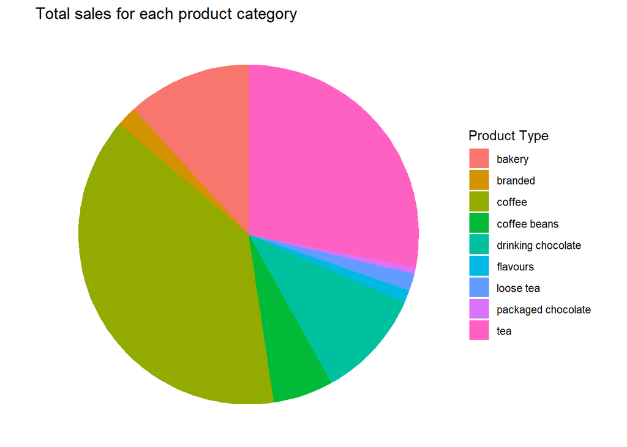

```r
# Calculating sums of Total_Sales for each product_type
product_sales <- sales_data %>%
  group_by(product_category) %>%
  summarise(Total_Sales = sum(Total_Sales)) %>%
  ungroup()


#Pie Chart
ggplot(product_sales, aes(x = "", y = Total_Sales, fill = product_category)) +
  geom_bar(width = 1, stat = "identity") +
  coord_polar("y", start = 0) +
  theme_void() +
  labs(fill = "Product Type",
       title = "Total sales for each product category")
```

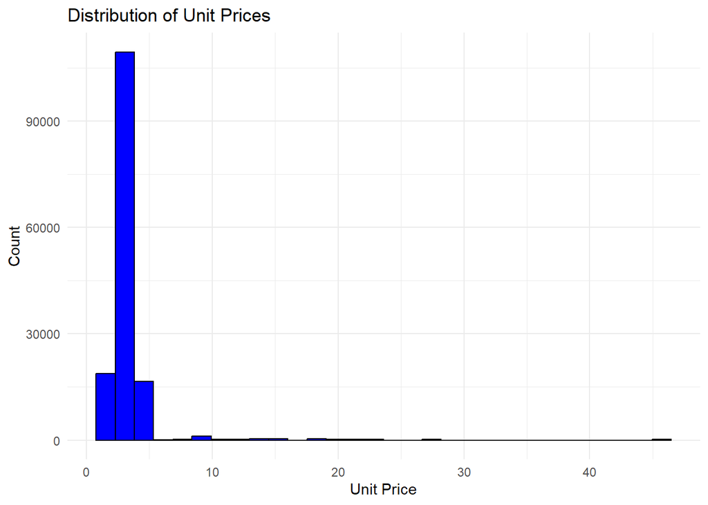

There appears to be a high concentration of unit prices in the lower range, close to the minimum price point, which suggests that most of the products are priced on the lower end of the scale. There are products with higher unit prices, but they are much less frequent as indicated by the single bars further along the x-axis.

```r
# To understand the distribution of 'unit_price'
ggplot(sales_data, aes(x = unit_price)) +
  geom_histogram(bins = 30, fill = "blue", color = "black") +
  labs(title = "Distribution of Unit Prices",
       x = "Unit Price",
       y = "Count") +
  theme_minimal()
```

[figure not shown]

```r
# Summarize data to find the total quantity sold and total revenue per product
product_sales_summary <- sales_data %>%
  group_by(product_detail) %>%
  summarise(
    Total_Quantity = sum(transaction_qty),
    Total_Revenue = sum(Total_Sales),
    .groups = 'drop'
  )

# Sort to find the most and least sold products
most_sold_products <- product_sales_summary %>%
  arrange(desc(Total_Quantity))


least_sold_products <- product_sales_summary %>%
  arrange(Total_Quantity)


# Sort to find which products generate the most and least revenue
most_revenue_products <- product_sales_summary %>%
  arrange(desc(Total_Revenue))

least_revenue_products <- product_sales_summary %>%
  arrange(Total_Revenue)


# Plotting the top 10 products by quantity sold

ggplot(most_sold_products[1:10,], aes(x = reorder(product_detail, Total_Quantity), y = Total_Quantity)) +
  geom_bar(stat = "identity", fill = "steelblue") +  # Use a single color for all bars
  coord_flip() +  # Horizontal bars
  labs(title = "Top 10 Most Sold Products",
       x = "Product",
       y = "Total Quantity Sold") +  # Remove the y-axis label as the product names are clear
  theme_minimal() +
  theme(legend.position = "none")  # Remove the legend
```

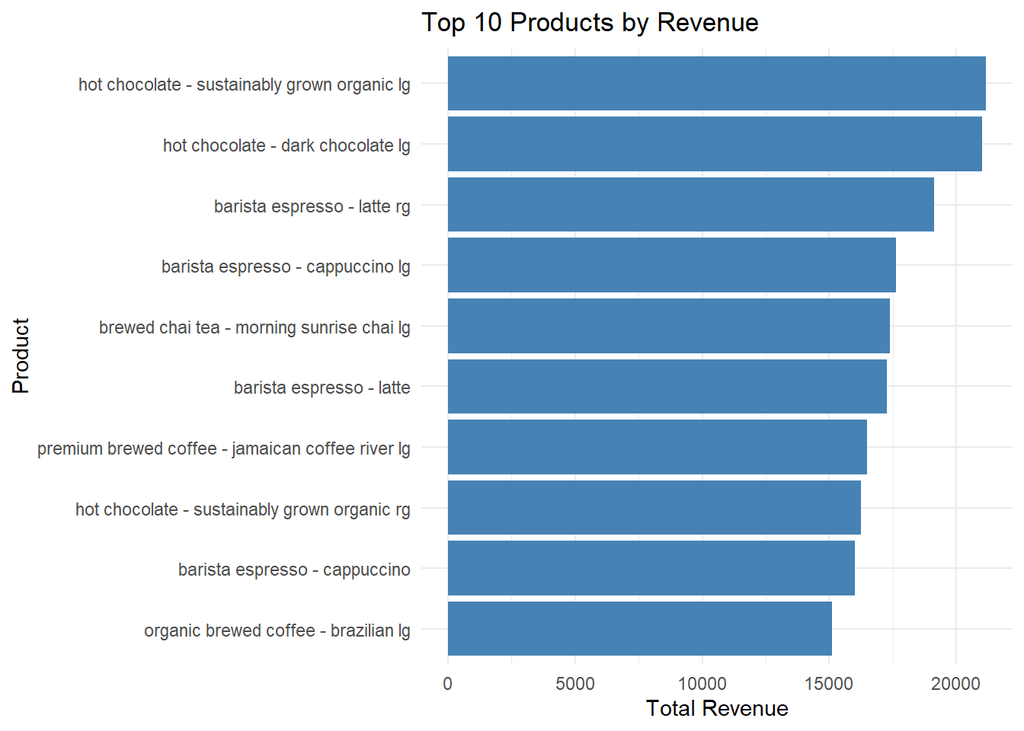

The product generating the most revenue is hot chocolate - sustainably grown organic lg.

```r
# Plotting the top 10 products by revenue
ggplot(most_revenue_products[1:10,], aes(x = reorder(product_detail, Total_Revenue), y = Total_Revenue)) +
  geom_bar(stat = "identity", fill = "steelblue") +  # Use a single color for all bars
  coord_flip() +  # Horizontal bars
  labs(title = "Top 10 Products by Revenue",
       x = "Product",
       y = "Total Revenue") +  # Remove the y-axis label as the product names are clear
  theme_minimal() +
  theme(legend.position = "none")  # Remove the legend
```

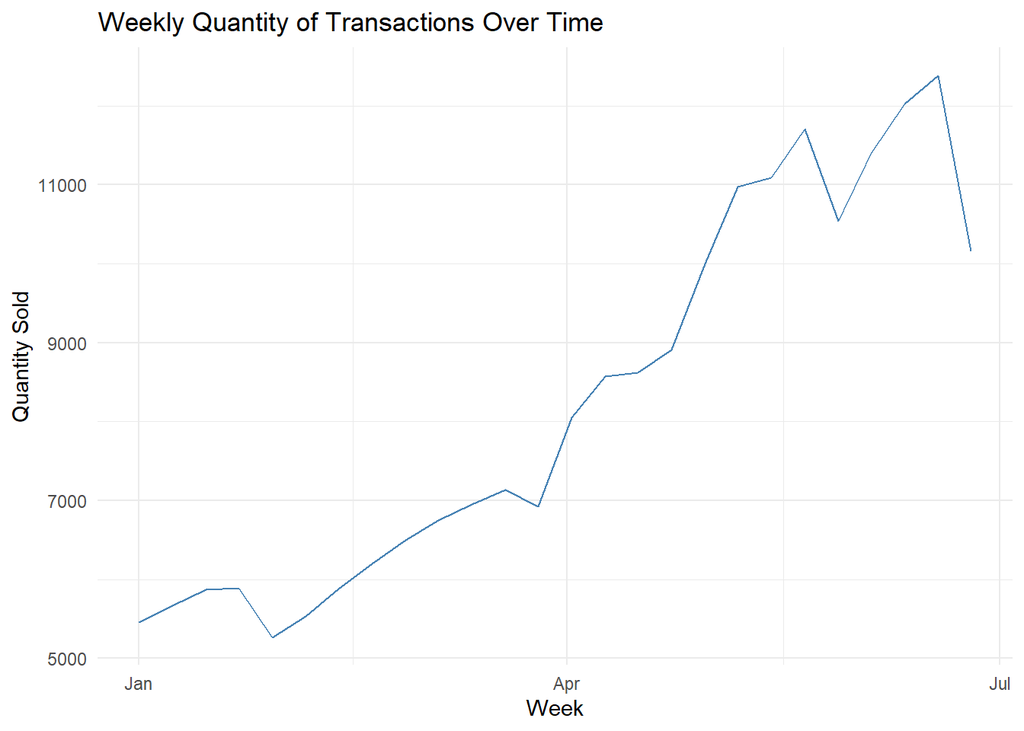

Transaction volume start low at the beginning of the year, gradually increasing until June, possibly due to seasonal trends.

```r
# Aggregate the weekly quantity sold
weekly_qty_sold <- sales_data %>%
  group_by(Week = floor_date(transaction_date, "week")) %>%
  summarise(Weekly_Quantity = sum(transaction_qty), .groups = 'drop')

# Line chart for weekly quantity sold over time
ggplot(weekly_qty_sold, aes(x = Week, y = Weekly_Quantity)) +
  geom_line(color = "steelblue") +  # Use a line to connect the points
  labs(title = "Weekly Quantity of Transactions Over Time",
       x = "Week",
       y = "Quantity Sold") +
  theme_minimal()
```

## Data Modeling

#We start our data modeling by preparing the daily sales data for time series analysis.

```r
###################Data modeling###########################

# Convert 'transaction_date' to a Date type if it isn't already
sales_data$transaction_date <- as.Date(sales_data$transaction_date)

# Aggregate sales data by date to get daily total sales
daily_sales <- sales_data %>%
  group_by(transaction_date) %>%
  summarise(Daily_Total_Sales = sum(Total_Sales), .groups = 'drop')
```

#Next, we create a ts object for our time series analysis and check for stationarity using the Augmented Dickey-Fuller Test.

```r
# Create a time series object from the daily sales totals
ts_sales <- ts(daily_sales$Daily_Total_Sales, frequency = 1)


# Check for stationarity; if the p-value is less than a significance level (e.g., 0.05), the series is considered stationary
adf_test_result <- adf.test(ts_sales)
```

#Based on the ADF test result, if our p-value is above 0.05, we perform differencing to achieve stationarity and retest.

```r
if(adf_test_result$p.value > 0.05) {
  ts_sales_diff <- diff(ts_sales)
  # Redo the stationarity test on the differenced data
  adf_test_result_diff <- adf.test(ts_sales_diff)
}
```

#Now we can fit an ARIMA model to our possibly differenced time series data using the auto.arima() function, which automatically selects the best fitting model.

```r
# Use the (differenced) series to fit an ARIMA model
# The auto.arima function will determine whether differencing is needed, so we can pass the original series
best_fit <- auto.arima(ts_sales)
```

#With our model ready, we now forecast the next 30 days of sales.

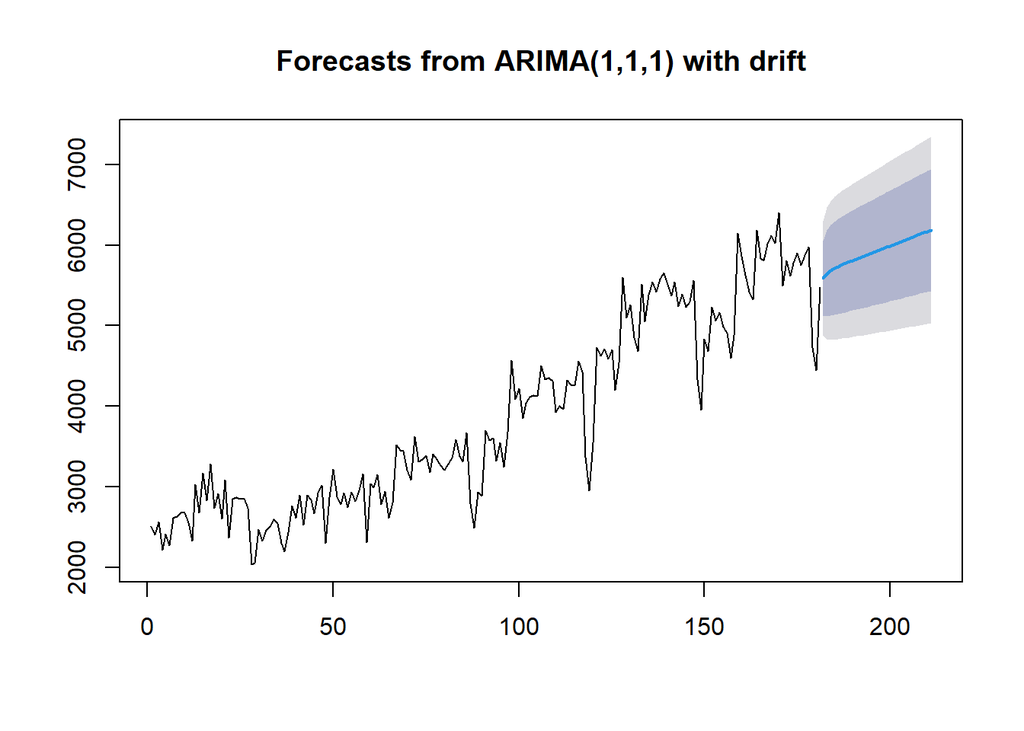

```r
# Forecast the next period (e.g., the next 30 days)
forecasted_sales <- forecast(best_fit, h = 30)


# Plot the forecast
plot(forecasted_sales)
```

#The blue line starting where the observed data ends represents the forecasted values from the ARIMA model. The fact that the model includes ‘drift’ suggests that there’s a trend component in the data that the model is picking up on, which allows the forecast to move upwards or downwards over time rather than staying flat.

#To ensure our model is reliable, we look at the fitted values versus the observed values.

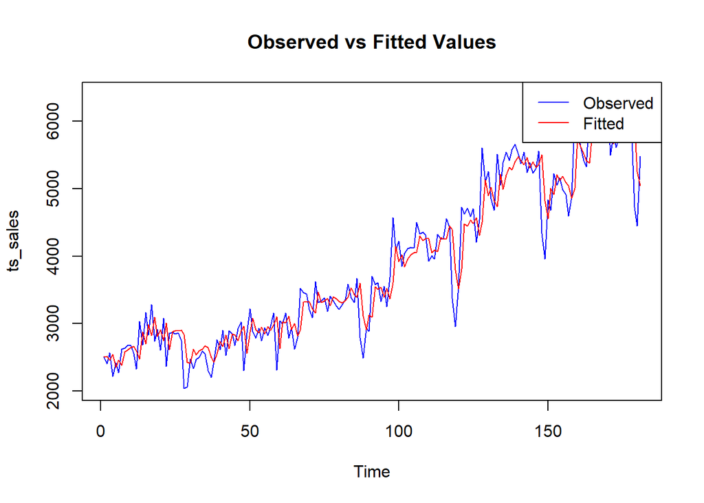

```r
# fitted ARIMA model
fitted_values <- fitted(best_fit)

# Create a time series plot comparing the observed and fitted values
plot(ts_sales, main="Observed vs Fitted Values", col="blue")
lines(fitted_values, col="red")
legend("topright", legend=c("Observed", "Fitted"), col=c("blue", "red"), lty=1)
```

#The plot above compares the actual daily sales against the sales estimated by our model. There is close alignment between the two lines which suggests a good model fit to the historical data.

#We also examine the residuals of our model to check for any patterns that could suggest model inadequacies.

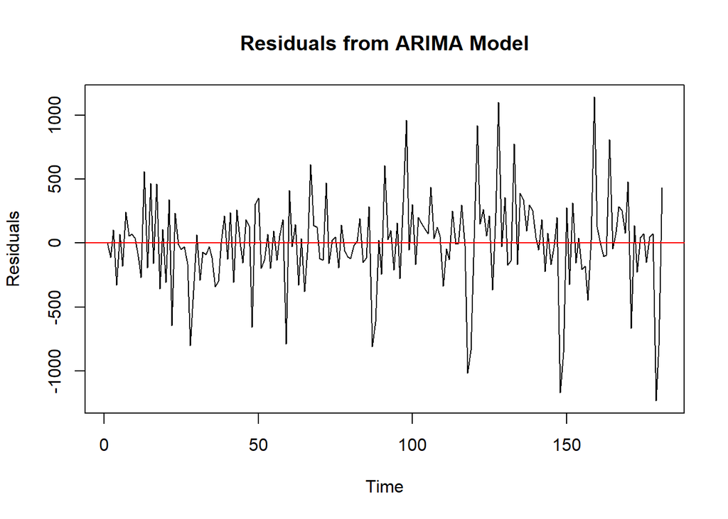

```r
# Calculate residuals
residuals <- residuals(best_fit)

# Basic plot of residuals
plot(residuals, main="Residuals from ARIMA Model", ylab="Residuals")
abline(h=0, col="red")
```

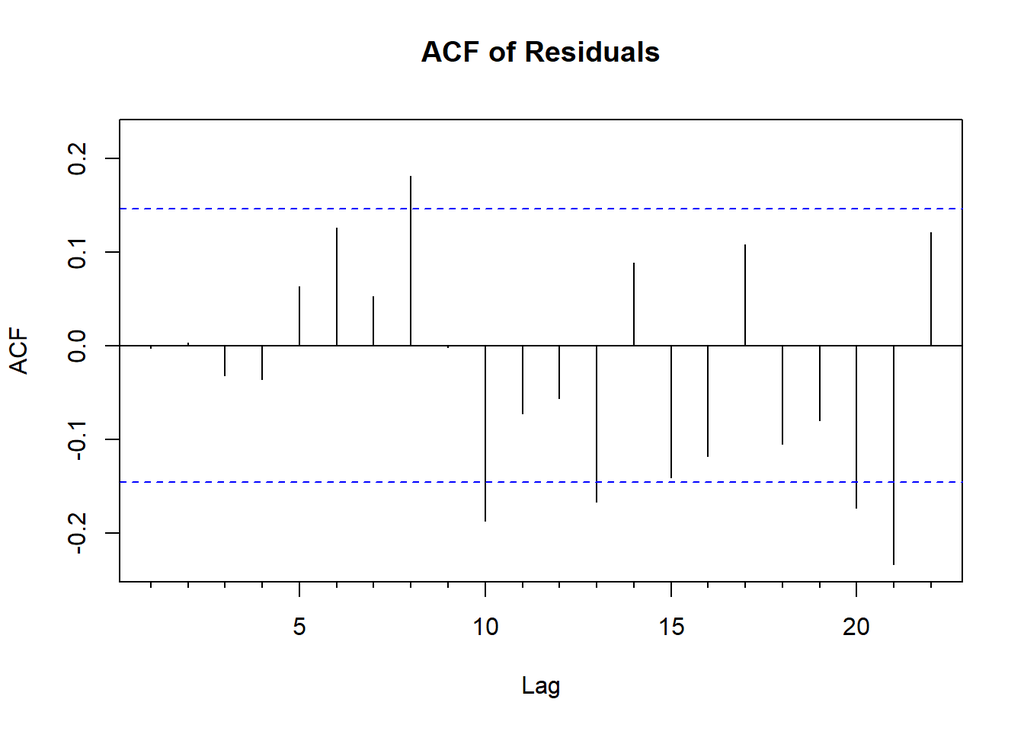

```r
# ACF and PACF plots to check for autocorrelation in residuals
Acf(residuals, main="ACF of Residuals")
```

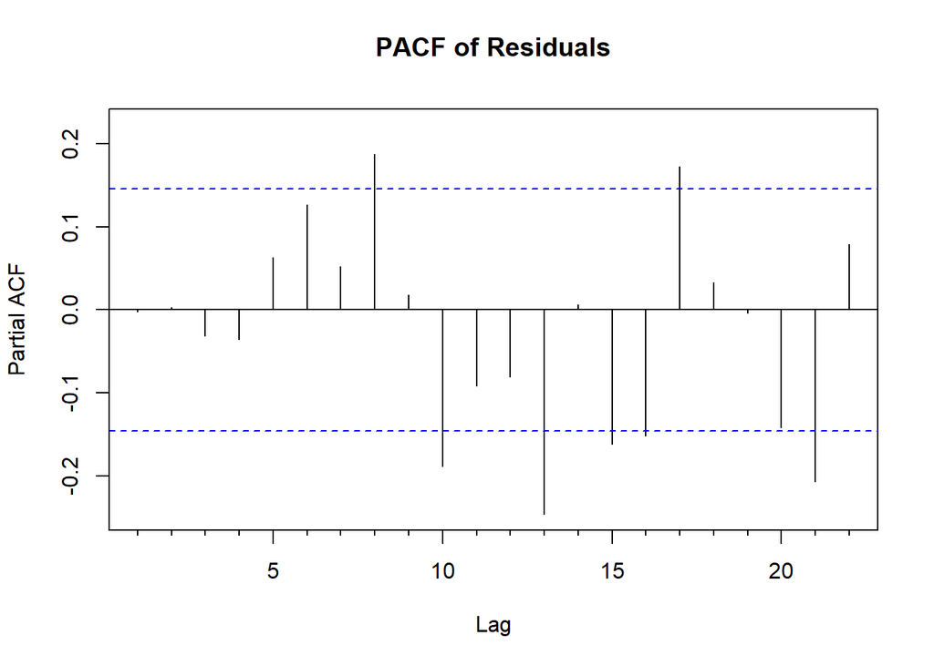

```r
Pacf(residuals, main="PACF of Residuals")
```